# prediction_assignment

George

January 29, 2017

# Data Capture

```r
training <- read.csv(url("https://d396qusza40orc.cloudfront.net/predmachlearn/pml-training.csv"))
testing <- read.csv(url("https://d396qusza40orc.cloudfront.net/predmachlearn/pml-testing.csv"))
```

# Data Cleaning

Let’s have a look at the data by creating a plot of missing data

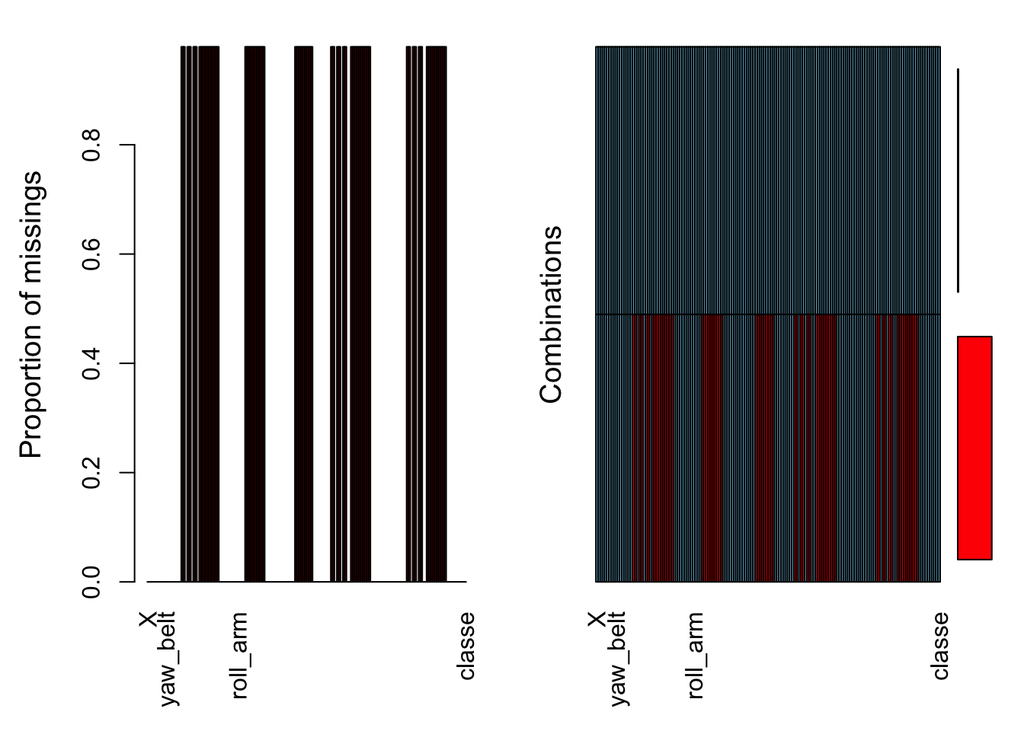

```r
aggr(training)
```

We see that many of the variables are empty or NA. Let’s identify these variables and remove them from the training set.

```r
na_count <-sapply(training, function(y) sum(length(which(is.na(y)))))
na_count <- data.frame(na_count)
na_count
```

```
##                          na_count
## X                               0
## user_name                       0
## raw_timestamp_part_1            0
## raw_timestamp_part_2            0
## cvtd_timestamp                  0
## new_window                      0
## num_window                      0
## roll_belt                       0
## pitch_belt                      0
## yaw_belt                        0
## total_accel_belt                0
## kurtosis_roll_belt              0
## kurtosis_picth_belt             0
## kurtosis_yaw_belt               0
## skewness_roll_belt              0
## skewness_roll_belt.1            0
## skewness_yaw_belt               0
## max_roll_belt               19216
## max_picth_belt              19216
## max_yaw_belt                    0
## min_roll_belt               19216
## min_pitch_belt              19216
## min_yaw_belt                    0
## amplitude_roll_belt         19216
## amplitude_pitch_belt        19216
## amplitude_yaw_belt              0
## var_total_accel_belt        19216
## avg_roll_belt               19216
## stddev_roll_belt            19216
## var_roll_belt               19216
## avg_pitch_belt              19216
## stddev_pitch_belt           19216
## var_pitch_belt              19216
## avg_yaw_belt                19216
## stddev_yaw_belt             19216
## var_yaw_belt                19216
## gyros_belt_x                    0
## gyros_belt_y                    0
## gyros_belt_z                    0
```

[output cut: 106 more lines]

```
## stddev_pitch_forearm        19216
## var_pitch_forearm           19216
## avg_yaw_forearm             19216
## stddev_yaw_forearm          19216
## var_yaw_forearm             19216
## gyros_forearm_x                 0
## gyros_forearm_y                 0
## gyros_forearm_z                 0
## accel_forearm_x                 0
## accel_forearm_y                 0
## accel_forearm_z                 0
## magnet_forearm_x                0
## magnet_forearm_y                0
## magnet_forearm_z                0
## classe                          0
```

Using the na_count I decided to remove the variables listed below. I’ve also decided to remove X and user name variables.

```r
names = c('avg_yaw_belt','max_roll_belt','max_picth_belt','min_roll_belt','min_pitch_belt','amplitude_roll_belt','amplitude_pitch_belt','var_total_accel_belt','avg_roll_belt','stddev_roll_belt','var_roll_belt','avg_pitch_belt','stddev_pitch_belt','var_pitch_belt','stddev_yaw_belt','var_yaw_belt','var_accel_arm','avg_roll_arm','stddev_roll_arm','var_roll_arm','avg_pitch_arm','stddev_pitch_arm','var_pitch_arm','avg_yaw_arm','stddev_yaw_arm','var_yaw_arm','max_roll_arm','max_picth_arm','max_yaw_arm','min_roll_arm','min_pitch_arm','min_yaw_arm','amplitude_roll_arm','amplitude_pitch_arm','amplitude_yaw_arm','max_roll_dumbbell','max_picth_dumbbell','min_roll_dumbbell','min_pitch_dumbbell','amplitude_roll_dumbbell','amplitude_pitch_dumbbell','var_accel_dumbbell','avg_roll_dumbbell','stddev_roll_dumbbell','var_roll_dumbbell','avg_pitch_dumbbell','stddev_pitch_dumbbell','var_pitch_dumbbell','avg_yaw_dumbbell','stddev_yaw_dumbbell','var_yaw_dumbbell','max_roll_forearm','max_picth_forearm','min_roll_forearm','min_pitch_forearm','amplitude_roll_forearm','amplitude_pitch_forearm','var_accel_forearm','avg_roll_forearm','stddev_roll_forearm','var_roll_forearm','avg_pitch_forearm','stddev_pitch_forearm', 'var_pitch_forearm','avg_yaw_forearm','stddev_yaw_forearm','var_yaw_forearm','skewness_pitch_forearm','skewness_yaw_forearm','max_yaw_forearm','min_yaw_forearm','amplitude_yaw_forearm','kurtosis_roll_forearm','kurtosis_picth_forearm','kurtosis_yaw_forearm','skewness_roll_forearm','skewness_yaw_dumbbell','max_yaw_dumbbell','min_yaw_dumbbell','amplitude_yaw_dumbbell','kurtosis_picth_dumbbell','kurtosis_yaw_dumbbell','skewness_roll_dumbbell','skewness_pitch_dumbbell','kurtosis_roll_dumbbell','kurtosis_roll_arm','kurtosis_picth_arm','kurtosis_yaw_arm','skewness_pitch_arm','amplitude_yaw_belt','kurtosis_yaw_belt','skewness_roll_belt','skewness_roll_belt.1','skewness_yaw_belt','max_yaw_belt','min_yaw_belt','kurtosis_roll_belt','kurtosis_picth_belt','X','user_name','skewness_roll_arm','skewness_yaw_arm')

training <- training %>% select(-one_of(names))
```

Explore how the plot of missing values looks like.

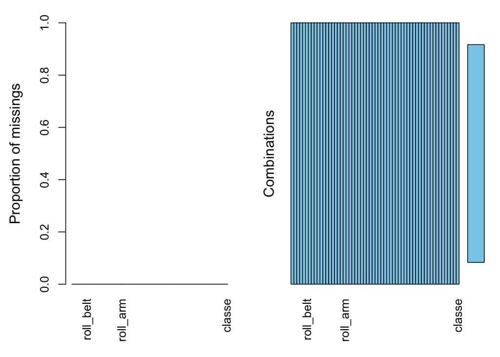

```r
aggr(training)
```

Count the appearances of each classe in the training and perform the same cleaning procedure at the test data set.

```r
count(training, 'classe')
```

```
##   classe freq
## 1      A 5580
## 2      B 3797
## 3      C 3422
## 4      D 3216
## 5      E 3607
```

```r
testing <- testing %>% select(-one_of(names))
```

# Apply Model

We will fit a classification tree using the Recursive Partitioning and Regression Trees model

```r
model <- train(classe ~., method="rpart", data = training)
prediction <- predict(model,newdata = testing)
prediction
```

```
##  [1] B A C A C C C C A A C C C A C C C B B C
## Levels: A B C D E
```

Submitted the results listed above and earned 9/20 points (45%).

Next step is to proceed with applying a random forest model. I will explore and remove variables with more than 53 factors because random forest can not handle categorical predictors with more than 53 categories.

```r
training <- training %>% select(-one_of(c('skewness_roll_arm','skewness_yaw_arm')))
testing <- testing %>% select(-one_of(c('skewness_roll_arm','skewness_yaw_arm','problem_id')))
```

Apply mondel

```r
rf_model <- randomForest(as.factor(classe) ~., data = training, importance=TRUE, ntree=2000)
```

I tried to predic classification but I was receiving an error that the type of predictors in new data do not match that of the training data. This is because some of the variables had different types and because we have different levels of factors for the categorical variables.

Here below I make necessary transformations

```r
testing$magnet_dumbbell_z<-as.numeric(testing$magnet_dumbbell_z)
testing$magnet_forearm_y<-as.numeric(testing$magnet_forearm_y)
testing$magnet_forearm_z<-as.numeric(testing$magnet_forearm_z)
levels(testing$cvtd_timestamp) <- levels(training$cvtd_timestamp)
levels(testing$new_window) <- levels(training$new_window)
```

```r
rf_prediction <- predict(rf_model, newdata = testing)
rf_prediction
```

```
##  1  2  3  4  5  6  7  8  9 10 11 12 13 14 15 16 17 18 19 20
##  B  A  B  A  A  E  D  B  A  A  B  C  B  A  E  E  A  B  B  B
## Levels: A B C D E
```

Submitted the results listed above and earned 20/20 points!